# Pertemuan 3 - Regresi dengan Peubah Lag

Dewi Kunthi Siswati Suryo

2023-09-10

## Packages

```r
library(dLagM)
library(dynlm)
library(MLmetrics)
library(lmtest)
library(car)
```

## Input Data

```r
data <- rio::import("https://raw.githubusercontent.com/dewidesis/MPDW-Prak/main/Pertemuan%203/NewDelhi.csv")
str(data)
```

```
## 'data.frame':    20 obs. of  4 variables:
##  $ t     : int  1 2 3 4 5 6 7 8 9 10 ...
##  $ Yt    : num  30.2 28.2 26.6 25 26 26 26 24 23 24 ...
##  $ Y(t-1): num  NA 30.2 28.2 26.6 25 26 26 26 24 23 ...
##  $ Xt    : num  0.0469 0.0465 0.0469 0.0482 0.0489 ...
```

```r
View(data)
```

## Pembagian Data

```r
#SPLIT DATA
train<-data[1:16,]
test<-data[17:20,]
```

```r
#data time series
train.ts<-ts(train)
test.ts<-ts(test)
data.ts<-ts(data)
```

## Model Koyck

```r
#MODEL KOYCK
model.koyck <- koyckDlm(x = train$Xt, y = train$Yt)
summary(model.koyck)
```

```
##
## Call:
## "Y ~ (Intercept) + Y.1 + X.t"
##
## Residuals:
##     Min      1Q  Median      3Q     Max
## -1.3117 -0.3662 -0.2458  0.4973  1.4783
##
## Coefficients:
##              Estimate Std. Error t value Pr(>|t|)
## (Intercept)   18.9840     4.3676   4.347 0.000951 ***
## Y.1            0.6423     0.1170   5.492 0.000138 ***
## X.t         -215.2870    55.8321  -3.856 0.002285 **
## ---
## Signif. codes:  0 '***' 0.001 '**' 0.01 '*' 0.05 '.' 0.1 ' ' 1
##
## Residual standard error: 0.879 on 12 degrees of freedom
## Multiple R-Squared: 0.819,   Adjusted R-squared: 0.7889
## Wald test: 28.31 on 2 and 12 DF,  p-value: 2.859e-05
##
## Diagnostic tests:
## NULL
##
##                           alpha     beta       phi
## Geometric coefficients:  53.074 -215.287 0.6423112
```

Dari hasil tersebut, didapat bahwa peubah intercept, $y_{t-1}$ dan $x_t$ memiliki nilai $P-Value<0.05$. Hal ini menunjukkan bahwa peubah intercept, $y_{t-1}$ dan $x_t$ berpengaruh signifikan terhadap $y$. Adapun model keseluruhannya adalah sebagai berikut

$$\hat{Y_t}=18.9840-215.2870X_t+0.6423Y_{t-1}$$

```r
AIC(model.koyck)
```

```
## [1] 43.35219
```

```r
BIC(model.koyck)
```

```
## [1] 46.18439
```

## Peramalan dan Akurasi

```r
#Koyck Forecasting
fore.koyck <- forecast(model = model.koyck, x=test$Xt, h=4)
fore.koyck
```

```
## $forecasts
## [1] 29.54081 28.80735 26.67897 24.01489
##
## $call
## forecast.koyckDlm(model = model.koyck, x = test$Xt, h = 4)
##
## attr(,"class")
## [1] "forecast.koyckDlm" "dLagM"
```

```r
#MAPE
mape.koyck <- MAPE(fore.koyck$forecasts, test$Yt)
#akurasi data training
GoF(model.koyck)
```

```
##              n       MAE           MPE       MAPE      sMAPE      MASE      MSE
## model.koyck 15 0.6345054 -0.0008439839 0.02470054 0.02478299 0.6729603 0.618125
##                   MRAE    GMRAE
## model.koyck 1966874992 282.4317
```

## Regression with Distributed Lag

# Pemodelan Lag (Lag=2)

```r
model.dlm <- dlm(x = train$Xt,y = train$Yt , q = 2)
summary(model.dlm)
```

```
##
## Call:
## lm(formula = model.formula, data = design)
##
## Residuals:
##     Min      1Q  Median      3Q     Max
## -1.3258 -0.3597 -0.1848  0.5178  0.9425
##
## Coefficients:
##             Estimate Std. Error t value Pr(>|t|)
## (Intercept)   46.503      2.449  18.991 3.56e-09 ***
## x.t          217.766    167.675   1.299    0.223
## x.1         -125.024    296.243  -0.422    0.682
## x.2         -534.162    186.874  -2.858    0.017 *
## ---
## Signif. codes:  0 '***' 0.001 '**' 0.01 '*' 0.05 '.' 0.1 ' ' 1
##
## Residual standard error: 0.7214 on 10 degrees of freedom
## Multiple R-squared:  0.8897, Adjusted R-squared:  0.8566
## F-statistic: 26.89 on 3 and 10 DF,  p-value: 4.211e-05
##
## AIC and BIC values for the model:
##        AIC      BIC
## 1 35.87425 39.06953
```

Dari hasil diatas, didapat bahwa $P-value$ dari intercept dan $x_{t-2}<0.05$. Hal ini menunjukkan bahwa intercept dan $x_{t-2}$ berpengaruh signifikan terhadap $y_t$. Adapun model keseluruhan yang terbentuk adalah sebagai berikut

$$\hat{Y_t}=46.503+217.766X_t-125.024X_{t-1}-534.162X_{t-2}$$

```r
AIC(model.dlm)
```

```
## [1] 35.87425
```

```r
BIC(model.dlm)
```

```
## [1] 39.06953
```

## Peramalan dan Akurasi

```r
fore.dlm <- forecast(model = model.dlm, x=test$Xt, h=4)
fore.dlm
```

```
## $forecasts
## [1] 29.07400 30.33465 32.09846 29.76624
##
## $call
## forecast.dlm(model = model.dlm, x = test$Xt, h = 4)
##
## attr(,"class")
## [1] "forecast.dlm" "dLagM"
```

```r
# MAPE Model DLM
mape.dlm <- MAPE(fore.dlm$forecasts, test$Yt)

# akurasi data training
GoF(model.dlm)
```

```
##            n       MAE           MPE       MAPE      sMAPE     MASE      MSE
## model.dlm 14 0.5266587 -0.0005561494 0.02037996 0.02035721 0.590221 0.371682
##                 MRAE    GMRAE
## model.dlm 1596341628 440.3444
```

## Lag Optimum

```r
#Penentuan lag optimum
finiteDLMauto(formula = Yt ~ Xt,
              data = data.frame(train), q.min = 1, q.max = 6,
              model.type = "dlm", error.type = "AIC", trace = F)
```

```
##   q - k    MASE      AIC      BIC    GMRAE   MBRAE R.Adj.Sq Ljung-Box
## 6     6 0.20844 20.64393 23.36719 17.23989 0.27642  0.92473 0.1726567
```

Berdasarkan output tersebut, lag optimum didapatkan ketika lag=6. Selanjutnya dilakukan pemodelan untuk lag=6

```r
#model dlm dengan lag optimum
model.dlm2 <- dlm(x = train$Xt,y = train$Yt , q = 6)
summary(model.dlm2)
```

```
##
## Call:
## lm(formula = model.formula, data = design)
##
## Residuals:
##        1        2        3        4        5        6        7        8
##  0.55166 -0.53693 -0.17728  0.26723 -0.10036  0.10920  0.03418 -0.19055
##        9       10
## -0.03708  0.07993
##
## Coefficients:
##             Estimate Std. Error t value Pr(>|t|)
## (Intercept)   38.429      6.952   5.528   0.0312 *
## x.t          320.067    217.452   1.472   0.2789
## x.1         -349.019    304.692  -1.145   0.3706
## x.2         -348.206    291.171  -1.196   0.3543
## x.3          173.741    300.803   0.578   0.6219
## x.4         -108.600    315.745  -0.344   0.7637
## x.5         -496.701    330.527  -1.503   0.2718
## x.6          539.462    252.007   2.141   0.1656
## ---
## Signif. codes:  0 '***' 0.001 '**' 0.01 '*' 0.05 '.' 0.1 ' ' 1
##
## Residual standard error: 0.6175 on 2 degrees of freedom
## Multiple R-squared:  0.9833, Adjusted R-squared:  0.9247
## F-statistic:  16.8 on 7 and 2 DF,  p-value: 0.05733
##
## AIC and BIC values for the model:
##        AIC      BIC
## 1 20.64393 23.36719
```

Dari hasil diatas, didapat bahwa $P-value$ dari $intercept<0.05$. Hal ini menunjukkan bahwa intercept berpengaruh signifikan terhadap $y_t$. Adapun model keseluruhan yang terbentuk adalah sebagai berikut

$$\hat{Y_t}=38.429+320.067X_t+...+539.462X_{t-6}$$

```r
AIC(model.dlm2)
```

```
## [1] 20.64393
```

```r
BIC(model.dlm2)
```

```
## [1] 23.36719
```

```r
# peramalan dan akurasi
fore.dlm2 <- forecast(model = model.dlm2, x=test$Xt, h=4)
mape.dlm2<- MAPE(fore.dlm2$forecasts, test$Yt)
# akurasi data training
GoF(model.dlm2)
```

```
##             n       MAE           MPE        MAPE       sMAPE      MASE
## model.dlm2 10 0.2084391 -0.0001369231 0.008251768 0.008251352 0.2084391
##                   MSE      MRAE    GMRAE
## model.dlm2 0.07626934 130014220 17.23989
```

Model tersebut merupakan model yang sangat baik dengan nilai MAPE yang kurang dari 10%.

## Model AUtoregressive

```r
#Model ardl
model.ardl <- ardlDlm(x = train$Xt, y = train$Yt, p = 1 , q = 1)
summary(model.ardl)
```

```
##
## Time series regression with "ts" data:
## Start = 2, End = 16
##
## Call:
## dynlm(formula = as.formula(model.text), data = data, start = 1)
##
## Residuals:
##     Min      1Q  Median      3Q     Max
## -1.2268 -0.3650 -0.2688  0.4692  1.2225
##
## Coefficients:
##              Estimate Std. Error t value Pr(>|t|)
## (Intercept)   24.3261     5.5689   4.368  0.00112 **
## X.t          115.6671   188.2207   0.615  0.55136
## X.1         -363.5638   214.3730  -1.696  0.11798
## Y.1            0.5023     0.1395   3.600  0.00417 **
## ---
## Signif. codes:  0 '***' 0.001 '**' 0.01 '*' 0.05 '.' 0.1 ' ' 1
##
## Residual standard error: 0.8112 on 11 degrees of freedom
## Multiple R-squared:  0.8587, Adjusted R-squared:  0.8202
## F-statistic: 22.29 on 3 and 11 DF,  p-value: 5.597e-05
```

Hasil di atas menunjukkan bahwa peubah intercept dan $y_{t-1}$, hasil uji t menunjukkan nilai-p pada peubah $<0.05$ Hal ini menunjukkan bahwa peubah intercept dan $y_{t-1}$ berpengaruh signifikan terhadap $y_t$, sementara $x_{t}$ dan $x_{t-1}$ tidak berpengaruh signifikan terhadap $y_t$. Model keseluruhannya adalah sebagai berikut:
$$\hat{Y}=24.3261+115.6671X_t-363.5638X_{t-1}+0.5023Y_{t-1}$$

```r
AIC(model.ardl)
```

```
## [1] 41.6368
```

```r
BIC(model.ardl)
```

```
## [1] 45.17705
```

## Peramalan dan Akurasi

```r
fore.ardl <- forecast(model = model.ardl, x=test$Xt, h=4)
fore.ardl
```

```
## $forecasts
## [1] 29.11397 30.23865 29.86876 27.58109
##
## $call
## forecast.ardlDlm(model = model.ardl, x = test$Xt, h = 4)
##
## attr(,"class")
## [1] "forecast.ardlDlm" "dLagM"
```

```r
mape.ardl <- MAPE(fore.ardl$forecasts, test$Yt)
mape.ardl
```

```
## [1] 0.05291343
```

```r
# akurasi data training
GoF(model.ardl)
```

```
##             n       MAE           MPE       MAPE      sMAPE      MASE       MSE
## model.ardl 15 0.5679237 -0.0007301233 0.02179799 0.02181624 0.6023433 0.4825084
##                  MRAE    GMRAE
## model.ardl 1549362490 212.4193
```

## Lag Optimum

```r
# penentuan lag optimum
model.ardl.opt <- ardlBoundOrders(data = data.frame(data), ic = "AIC",
                                  formula = Yt ~ Xt)
min_p=c()
for(i in 1:6){
  min_p[i]=min(model.ardl.opt$Stat.table[[i]])
}
q_opt=which(min_p==min(min_p, na.rm = TRUE))
p_opt=which(model.ardl.opt$Stat.table[[q_opt]] ==
              min(model.ardl.opt$Stat.table[[q_opt]], na.rm = TRUE))
data.frame("q_optimum" = q_opt, "p_optimum" = p_opt,
           "AIC"=model.ardl.opt$min.Stat)
```

```
##   q_optimum p_optimum      AIC
## 1         1         6 -54.3281
```

Dari tabel di atas, dapat terlihat bahwa nilai AIC terendah didapat ketika $p=6$ dan $q=1$, yaitu sebesar `-54.3281`. Artinya, model autoregressive optimum didapat ketika $p=6$ dan $q=1$.

Selanjutnya dapat dilakukan pemodelan dengan nilai $p$ dan $q$ optimum seperti inisialisasi di langkah sebelumnya.

## Pemodelan DLM & ARDL dengan Library `dynlm`

```r
#sama dengan model dlm q=1
cons_lm1 <- dynlm(Yt ~ Xt+L(Xt),data = train.ts)
#sama dengan model ardl p=1 q=0
cons_lm2 <- dynlm(Yt ~ Xt+L(Yt),data = train.ts)
#sama dengan ardl p=1 q=1
cons_lm3 <- dynlm(Yt ~ Xt+L(Xt)+L(Yt),data = train.ts)
#sama dengan dlm p=2
cons_lm4 <- dynlm(Yt ~ Xt+L(Xt)+L(Xt,2),data = train.ts)
```

### Ringkasan Model

```r
summary(cons_lm1)
```

```
##
## Time series regression with "ts" data:
## Start = 2, End = 16
##
## Call:
## dynlm(formula = Yt ~ Xt + L(Xt), data = train.ts)
##
## Residuals:
##      Min       1Q   Median       3Q      Max
## -1.66021 -0.72690  0.04551  0.22951  2.41418
##
## Coefficients:
##             Estimate Std. Error t value Pr(>|t|)
## (Intercept)   42.454      3.363  12.626 2.74e-08 ***
## Xt           502.405    218.418   2.300  0.04018 *
## L(Xt)       -853.828    233.978  -3.649  0.00333 **
## ---
## Signif. codes:  0 '***' 0.001 '**' 0.01 '*' 0.05 '.' 0.1 ' ' 1
##
## Residual standard error: 1.146 on 12 degrees of freedom
## Multiple R-squared:  0.6923, Adjusted R-squared:  0.641
## F-statistic:  13.5 on 2 and 12 DF,  p-value: 0.0008492
```

```r
summary(cons_lm2)
```

```
##
## Time series regression with "ts" data:
## Start = 2, End = 16
##
## Call:
## dynlm(formula = Yt ~ Xt + L(Yt), data = train.ts)
##
## Residuals:
##     Min      1Q  Median      3Q     Max
## -1.3351 -0.3673 -0.1422  0.5380  1.3982
##
## Coefficients:
##              Estimate Std. Error t value Pr(>|t|)
## (Intercept)   17.6793     4.2544   4.156  0.00133 **
## Xt          -192.2175    53.4377  -3.597  0.00367 **
## L(Yt)          0.6526     0.1159   5.632  0.00011 ***
## ---
## Signif. codes:  0 '***' 0.001 '**' 0.01 '*' 0.05 '.' 0.1 ' ' 1
##
## Residual standard error: 0.8723 on 12 degrees of freedom
## Multiple R-squared:  0.8218, Adjusted R-squared:  0.7921
## F-statistic: 27.67 on 2 and 12 DF,  p-value: 3.201e-05
```

```r
summary(cons_lm3)
```

```
##
## Time series regression with "ts" data:
## Start = 2, End = 16
##
## Call:
## dynlm(formula = Yt ~ Xt + L(Xt) + L(Yt), data = train.ts)
##
## Residuals:
##     Min      1Q  Median      3Q     Max
## -1.2268 -0.3650 -0.2688  0.4692  1.2225
##
## Coefficients:
##              Estimate Std. Error t value Pr(>|t|)
## (Intercept)   24.3261     5.5689   4.368  0.00112 **
## Xt           115.6671   188.2207   0.615  0.55136
## L(Xt)       -363.5638   214.3730  -1.696  0.11798
## L(Yt)          0.5023     0.1395   3.600  0.00417 **
## ---
## Signif. codes:  0 '***' 0.001 '**' 0.01 '*' 0.05 '.' 0.1 ' ' 1
##
## Residual standard error: 0.8112 on 11 degrees of freedom
## Multiple R-squared:  0.8587, Adjusted R-squared:  0.8202
## F-statistic: 22.29 on 3 and 11 DF,  p-value: 5.597e-05
```

```r
summary(cons_lm4)
```

```
##
## Time series regression with "ts" data:
## Start = 3, End = 16
##
## Call:
## dynlm(formula = Yt ~ Xt + L(Xt) + L(Xt, 2), data = train.ts)
##
## Residuals:
##     Min      1Q  Median      3Q     Max
## -1.3258 -0.3597 -0.1848  0.5178  0.9425
##
## Coefficients:
##             Estimate Std. Error t value Pr(>|t|)
## (Intercept)   46.503      2.449  18.991 3.56e-09 ***
## Xt           217.766    167.675   1.299    0.223
## L(Xt)       -125.024    296.243  -0.422    0.682
## L(Xt, 2)    -534.162    186.874  -2.858    0.017 *
## ---
## Signif. codes:  0 '***' 0.001 '**' 0.01 '*' 0.05 '.' 0.1 ' ' 1
##
## Residual standard error: 0.7214 on 10 degrees of freedom
## Multiple R-squared:  0.8897, Adjusted R-squared:  0.8566
## F-statistic: 26.89 on 3 and 10 DF,  p-value: 4.211e-05
```

### SSE

```r
deviance(cons_lm1)
```

```
## [1] 15.76717
```

```r
deviance(cons_lm2)
```

```
## [1] 9.130076
```

```r
deviance(cons_lm3)
```

```
## [1] 7.237626
```

```r
deviance(cons_lm4)
```

```
## [1] 5.203548
```

## Perbandingan Model

```r
akurasi <- matrix(c(mape.koyck, mape.dlm, mape.dlm2, mape.ardl))
row.names(akurasi)<- c("Koyck","DLM 1","DLM 2","Autoregressive")
colnames(akurasi) <- c("MAPE")
akurasi
```

```
##                      MAPE
## Koyck          0.04248304
## DLM 1          0.09430430
## DLM 2          0.07053442
## Autoregressive 0.05291343
```

Berdasarkan nilai MAPE, model paling optimum didapat pada Model Koyck karena memiliki nilai MAPE yang terkecil.

### Plot

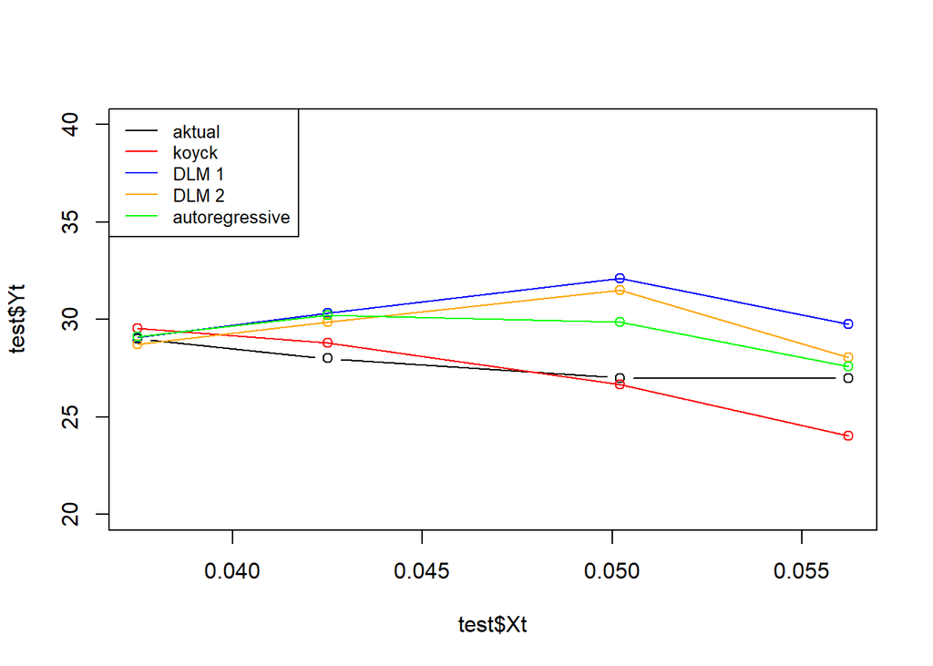

```r
par(mfrow=c(1,1))
plot(test$Xt, test$Yt, type="b", col="black", ylim=c(20,40))
points(test$Xt, fore.koyck$forecasts,col="red")
lines(test$Xt, fore.koyck$forecasts,col="red")
points(test$Xt, fore.dlm$forecasts,col="blue")
lines(test$Xt, fore.dlm$forecasts,col="blue")
points(test$Xt, fore.dlm2$forecasts,col="orange")
lines(test$Xt, fore.dlm2$forecasts,col="orange")
points(test$Xt, fore.ardl$forecasts,col="green")
lines(test$Xt, fore.ardl$forecasts,col="green")
legend("topleft",c("aktual", "koyck","DLM 1","DLM 2", "autoregressive"), lty=1, col=c("black","red","blue","orange","green"), cex=0.8)
```

Berdasarkan plot tersebut, terlihat bahwa plot yang paling mendekati data aktualnya adalah Model koyck, sehingga dapat disimpulkan model terbaik dalam hal ini adalah model regresi koyck